# Reproducible Research - Week 1 course project

## Imputing missing values

##### 1. Calculate and report the total number of missing values in the dataset

```r
numMissingValues <- sum(is.na(actdf))
```

- Number of missing values: 2304

##### 2. Devise a strategy for filling in all of the missing values in the dataset.

- Using the mean of the interval for filling the missing values, new dataset is created

##### 3. Create a new dataset that is equal to the original dataset but with the missing data filled in.

```r
new_actdf<- actdf
missVal<- is.na(new_actdf$steps)
avgsteps<-tapply(new_actdf$steps, new_actdf$interval, FUN = mean, na.rm=TRUE, simplify = TRUE)
new_actdf$steps[missVal]<-avgsteps[as.character(new_actdf$interval[missVal])]
```

##### 4. Make a histogram of the total number of steps taken each day

[figure not shown]

```r
agg1 <- aggregate(steps~date, new_actdf, FUN = sum, na.action = na.omit)
g<- ggplot(data=agg, aes(steps))
g + geom_histogram(fill = "firebrick", binwidth = 1000) + labs(title = "Histogram of Steps per day, including missing values", x = "Steps per day", y = "Frequency")
```

```r
stepsByDayMeanImputed <- mean(agg$steps, na.rm = TRUE)
stepsByDayMedianImputed <- median(agg$steps, na.rm = TRUE)
```

## Are there differences in activity patterns between weekdays and weekends?

##### 1. Create a new factor variable in the dataset with two levels weekday and weekend indicating whether a given date is a weekday or weekend day.

```r
days<-c("Monday", "Tuesday", "Wednesday", "Thursday", "Friday")
actdf$day<-ifelse(is.element(weekdays(as.Date(actdf$date)), days), "Weekday", "Weekend")
```

##### 2. Make a panel plot containing a time series plot

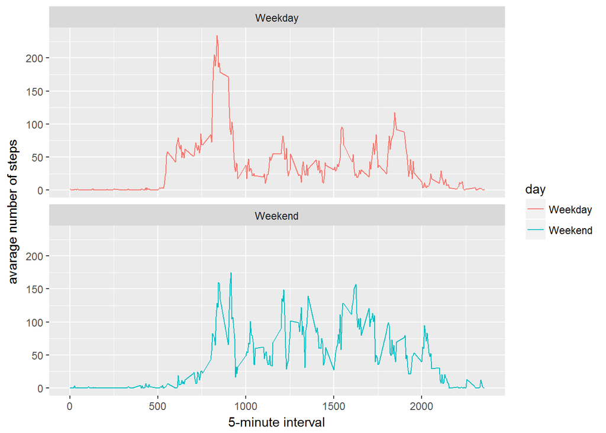

```r
avg1 <- aggregate(steps~interval+day, actdf, FUN = mean, na.action = na.omit)
g <- ggplot(data = avg1, aes(y=steps, x=interval, color = day))
g + facet_wrap(~avg1$day, nrow=2, ncol=1) + geom_line() +
    xlab("5-minute interval") +
    ylab("avarage number of steps")
```